# House Price Prediction

Jose Miguel Nuno de la Rosa Ortiz

July 14, 2017

```r
library(knitr)
library(lattice)
library(plyr)
library(ggplot2)
library(reshape2)
library(e1071)
library(ranger)
library(caret)
library(Formula)
library(ipred)
library(corrplot)
library(MASS)
set.seed(123)
```

The aim of this study is to expose the characteristics of a house and how these characteristics influence in the price of a house. Later on, I will attempt to forecast the price of the house attending to the house characteristics. The data belongs to Idealista and is a sample of houses located in Las Rozas municipality.

```r
flat <- dget('residential.sale.flat.pickle')
house <- dget('residential.sale.house.pickle')

flat$ISFLAT <- rep(1, nrow(flat))
house$ISFLAT <- rep(0, nrow(house))

rozas <- rbind(flat, house)

str(rozas)
```

```
## 'data.frame':    5424 obs. of  22 variables:
##  $ CONSTRUCTEDAREA      : num  120 58 72 170 70 75 135 100 176 137 ...
##  $ PRICE                : num  246415 129218 195329 391000 210000 ...
##  $ AREARANGETK          : int  5 2 3 8 3 3 6 4 8 6 ...
##  $ ROOMSID              : int  3 2 3 4 2 3 4 4 3 4 ...
##  $ HASAIRCONDITIONINGID : int  1 0 0 0 0 0 0 0 1 0 ...
##  $ HASPARKINGSPACEID    : int  0 1 1 1 1 1 1 0 1 1 ...
##  $ HASSWIMMINGPOOLID    : int  1 1 1 1 1 1 1 0 1 1 ...
##  $ HASTERRACEID         : int  1 0 0 1 1 0 0 1 0 1 ...
##  $ HASGARDENID          : int  1 1 1 1 0 1 1 0 0 1 ...
##  $ HASLIFTID            : int  1 1 1 1 1 1 1 1 1 1 ...
##  $ ISINVOICEID          : int  1 0 0 1 1 1 1 1 1 1 ...
##  $ STATEID              : int  4 4 4 4 4 4 4 4 4 4 ...
##  $ PROPERTYTYPEID       : int  1 1 1 1 1 1 1 1 1 1 ...
##  $ NEWDEVELOPMENTID     : int  -1 -1 -1 -1 -1 -1 -1 -1 -1 -1 ...
##  $ ISFROMBANKID         : int  0 0 0 0 0 0 0 0 0 0 ...
##  $ ENERGYCERTIFICATIONID: int  9 9 9 9 9 9 9 9 9 9 ...
##  $ BUILTTYPEID          : int  1 3 3 3 3 3 3 3 3 3 ...
##  $ FLATLOCATIONID       : int  1 1 1 1 1 1 1 1 1 1 ...
##  $ LEVEL8ID             : Factor w/ 1 level "ff8a069f498c1352f7e7d9e9dbe422868753e430": 1 1 1 1 1 1 1 1 1 1 ...
##  $ YEAR                 : Factor w/ 13 levels "2006","2007",..: 13 13 13 13 13 13 1 1 13 13 ...
##  $ SQ_PRICE             : num  2053 2228 2713 2300 3000 ...
##  $ ISFLAT               : num  1 1 1 1 1 1 1 1 1 1 ...
```

There are two datasets, one belongs to flats exclusively and the other one to houses. I created an additional variable which determines wether the entry is a house or a flat, this will keep the characteristic of the house whenever I merge the data row-wise.

Many variables appear as numeric when they should be as factor but it does not matter; I will transform to factors the variables that have more than two levels because I will apply the function *dummyVars* that will transform each level of a variable into a dummry variable. For example, if I have the variable *language: Spanish, English, French*, then *dummyVar* will output *Spanish: 0,1; English: 0,1; French: 0,1;* leaving untouched the ones that are not factors. Therefore, I do not want to declare binary functions as factors yet, otherwise I will get those variables separated into two binary variables.

There are also some variables that do not vary at all since they are related to identification tags rather than characteristics; they are constant along the whole sample, hence, I will drop those variables.

```r
rozas$STATEID <- NULL
rozas$LEVEL8ID <- NULL
rozas$PROPERTYTYPEID <- NULL
rozas$NEWDEVELOPMENTID <- NULL
rozas$ISFROMBANKID <- NULL

rozas$AREARANGETK <- as.factor(rozas$AREARANGETK)
rozas$FLATLOCATIONID <- as.factor(rozas$FLATLOCATIONID)
rozas$ENERGYCERTIFICATIONID <- as.factor(rozas$ENERGYCERTIFICATIONID)
rozas$BUILTTYPEID <- as.factor(rozas$BUILTTYPEID)

dummies <- dummyVars(PRICE ~ ., data = rozas)
rozas_processed <- as.data.frame(predict(dummies, rozas))

str(rozas_processed)
```

```
## 'data.frame':    5424 obs. of  56 variables:
##  $ CONSTRUCTEDAREA         : num  120 58 72 170 70 75 135 100 176 137 ...
##  $ AREARANGETK.1           : num  0 0 0 0 0 0 0 0 0 0 ...
##  $ AREARANGETK.2           : num  0 1 0 0 0 0 0 0 0 0 ...
##  $ AREARANGETK.3           : num  0 0 1 0 1 1 0 0 0 0 ...
##  $ AREARANGETK.4           : num  0 0 0 0 0 0 0 1 0 0 ...
##  $ AREARANGETK.5           : num  1 0 0 0 0 0 0 0 0 0 ...
##  $ AREARANGETK.6           : num  0 0 0 0 0 0 1 0 0 1 ...
##  $ AREARANGETK.7           : num  0 0 0 0 0 0 0 0 0 0 ...
##  $ AREARANGETK.8           : num  0 0 0 1 0 0 0 0 1 0 ...
##  $ AREARANGETK.9           : num  0 0 0 0 0 0 0 0 0 0 ...
##  $ AREARANGETK.10          : num  0 0 0 0 0 0 0 0 0 0 ...
##  $ AREARANGETK.11          : num  0 0 0 0 0 0 0 0 0 0 ...
##  $ AREARANGETK.12          : num  0 0 0 0 0 0 0 0 0 0 ...
##  $ AREARANGETK.13          : num  0 0 0 0 0 0 0 0 0 0 ...
```

[output cut: 42 more lines]

As we can observe, before we had a variable called *year* and now we have a binary variable per level of the variable *year*. There are some funny things though, like the year 2100, this clearly must be dropped. Now it is time to declare as factor the binary variables that we left as numeric before, as well as all the new binary variables which haven been declared numeric by default.

When I used the *dummyVar* function, it worked like an *lm* function where I specify the response variable and the explanatory ones, so besides the new binary variables we lost the column of the price of houses which I will have to attach again to have the data frame with full information.

```r
rozas_processed$HASPARKINGSPACEID <- as.factor(rozas$HASPARKINGSPACEID)
rozas_processed$HASSWIMMINGPOOLID <- as.factor(rozas$HASSWIMMINGPOOLID)
rozas_processed$HASTERRACEID <- as.factor(rozas$HASTERRACEID)
rozas_processed$HASGARDENID <- as.factor(rozas$HASGARDENID)
rozas_processed$HASLIFTID <- as.factor(rozas$HASLIFTID)
rozas_processed$ISINVOICEID <- as.factor(rozas$ISINVOICEID)
rozas_processed$ISFLAT <- as.factor(rozas$ISFLAT)
rozas_processed$HASAIRCONDITIONINGID <- as.factor(rozas$HASAIRCONDITIONINGID)

cols <- c("AREARANGETK.1", "AREARANGETK.2", "AREARANGETK.3", "AREARANGETK.4", "AREARANGETK.5", "AREARANGETK.6" ,"AREARANGETK.7",
          "AREARANGETK.8", "AREARANGETK.9","AREARANGETK.10", "AREARANGETK.11", "AREARANGETK.12", "AREARANGETK.13", "AREARANGETK.14",
          "AREARANGETK.15", "ENERGYCERTIFICATIONID.-1", "ENERGYCERTIFICATIONID.1", "ENERGYCERTIFICATIONID.2",
          "ENERGYCERTIFICATIONID.3",  "ENERGYCERTIFICATIONID.4",  "ENERGYCERTIFICATIONID.5",  "ENERGYCERTIFICATIONID.6",
          "ENERGYCERTIFICATIONID.7", "ENERGYCERTIFICATIONID.8", "ENERGYCERTIFICATIONID.9", "ENERGYCERTIFICATIONID.10", "BUILTTYPEID.1",
          "BUILTTYPEID.2", "BUILTTYPEID.3", "FLATLOCATIONID.-1", "FLATLOCATIONID.1", "FLATLOCATIONID.2", "YEAR.2006", "YEAR.2007",
          "YEAR.2008", "YEAR.2009", "YEAR.2010", "YEAR.2011", "YEAR.2012", "YEAR.2013", "YEAR.2014", "YEAR.2015",
          "YEAR.2016", "YEAR.2017")

rozas_processed[cols] <- lapply(rozas_processed[cols], factor)

rozas_processed$YEAR.2100 <- NULL

rozas_2 <- data.frame(rozas$PRICE, rozas_processed)

str(rozas_2)
```

```
## 'data.frame':    5424 obs. of  56 variables:
##  $ rozas.PRICE             : num  246415 129218 195329 391000 210000 ...
##  $ CONSTRUCTEDAREA         : num  120 58 72 170 70 75 135 100 176 137 ...
##  $ AREARANGETK.1           : Factor w/ 2 levels "0","1": 1 1 1 1 1 1 1 1 1 1 ...
##  $ AREARANGETK.2           : Factor w/ 2 levels "0","1": 1 2 1 1 1 1 1 1 1 1 ...
##  $ AREARANGETK.3           : Factor w/ 2 levels "0","1": 1 1 2 1 2 2 1 1 1 1 ...
##  $ AREARANGETK.4           : Factor w/ 2 levels "0","1": 1 1 1 1 1 1 1 2 1 1 ...
##  $ AREARANGETK.5           : Factor w/ 2 levels "0","1": 2 1 1 1 1 1 1 1 1 1 ...
##  $ AREARANGETK.6           : Factor w/ 2 levels "0","1": 1 1 1 1 1 1 2 1 1 2 ...
##  $ AREARANGETK.7           : Factor w/ 2 levels "0","1": 1 1 1 1 1 1 1 1 1 1 ...
##  $ AREARANGETK.8           : Factor w/ 2 levels "0","1": 1 1 1 2 1 1 1 1 2 1 ...
##  $ AREARANGETK.9           : Factor w/ 2 levels "0","1": 1 1 1 1 1 1 1 1 1 1 ...
##  $ AREARANGETK.10          : Factor w/ 2 levels "0","1": 1 1 1 1 1 1 1 1 1 1 ...
##  $ AREARANGETK.11          : Factor w/ 2 levels "0","1": 1 1 1 1 1 1 1 1 1 1 ...
##  $ AREARANGETK.12          : Factor w/ 2 levels "0","1": 1 1 1 1 1 1 1 1 1 1 ...
```

[output cut: 42 more lines]

Variables are now perfectly defined; they are either numeric or binary with two levels. Before splitting data into train/test sets, it is good idea to fit a linear model in the whole dataset to infere some information by observing the hypothesis testing of the coefficientes of the linear model.

```r
linear_model <- lm(rozas.PRICE ~ ., data = rozas_2)
summary(linear_model)
```

```
##
## Call:
## lm(formula = rozas.PRICE ~ ., data = rozas_2)
##
## Residuals:
##     Min      1Q  Median      3Q     Max
## -699426  -43203    -474   42914  774234
##
## Coefficients: (4 not defined because of singularities)
##                             Estimate Std. Error t value Pr(>|t|)
## (Intercept)               -1.893e+05  5.135e+04  -3.687 0.000229 ***
## CONSTRUCTEDAREA            7.324e+02  5.932e+01  12.346  < 2e-16 ***
## AREARANGETK.11             1.715e+05  3.629e+04   4.725 2.36e-06 ***
## AREARANGETK.21             2.143e+05  2.821e+04   7.597 3.54e-14 ***
## AREARANGETK.31             2.283e+05  2.710e+04   8.422  < 2e-16 ***
## AREARANGETK.41             2.471e+05  2.662e+04   9.281  < 2e-16 ***
## AREARANGETK.51             2.591e+05  2.647e+04   9.789  < 2e-16 ***
## AREARANGETK.61             2.730e+05  2.672e+04  10.215  < 2e-16 ***
## AREARANGETK.71             2.914e+05  2.711e+04  10.749  < 2e-16 ***
## AREARANGETK.81             2.909e+05  2.774e+04  10.487  < 2e-16 ***
## AREARANGETK.91             2.861e+05  2.831e+04  10.106  < 2e-16 ***
## AREARANGETK.101            3.158e+05  2.951e+04  10.701  < 2e-16 ***
## AREARANGETK.111            2.236e+05  3.761e+04   5.944 2.95e-09 ***
## AREARANGETK.121           -1.127e+05  4.976e+04  -2.266 0.023515 *
## AREARANGETK.131           -5.075e+05  5.754e+04  -8.820  < 2e-16 ***
## AREARANGETK.141           -4.984e+05  7.773e+04  -6.412 1.56e-10 ***
## AREARANGETK.151                   NA         NA      NA       NA
## ROOMSID                    2.171e+04  3.685e+03   5.890 4.09e-09 ***
## HASAIRCONDITIONINGID1      5.170e+03  3.626e+03   1.426 0.153964
## HASPARKINGSPACEID1         2.543e+04  6.007e+03   4.234 2.33e-05 ***
## HASSWIMMINGPOOLID1        -1.443e+03  7.056e+03  -0.204 0.838018
## HASTERRACEID1              5.940e+03  4.117e+03   1.443 0.149209
## HASGARDENID1               9.062e+03  6.688e+03   1.355 0.175485
## HASLIFTID1                 3.978e+04  9.077e+03   4.383 1.19e-05 ***
## ISINVOICEID1               1.732e+04  4.570e+03   3.790 0.000152 ***
## ENERGYCERTIFICATIONID..11  9.891e+03  9.349e+03   1.058 0.290126
## ENERGYCERTIFICATIONID.11   1.997e+04  2.188e+04   0.913 0.361249
## ENERGYCERTIFICATIONID.21   1.064e+04  1.023e+04   1.041 0.297953
## ENERGYCERTIFICATIONID.31  -2.434e+04  2.143e+04  -1.136 0.256163
## ENERGYCERTIFICATIONID.41   5.130e+03  1.658e+04   0.309 0.756990
```

[output cut: 17 more lines]

```
## YEAR.20111                 5.383e+04  7.548e+03   7.132 1.12e-12 ***
## YEAR.20121                 2.235e+04  7.162e+03   3.120 0.001818 **
## YEAR.20131                 1.165e+04  7.841e+03   1.485 0.137547
## YEAR.20141                 1.222e+04  8.328e+03   1.467 0.142461
## YEAR.20151                 1.851e+04  8.284e+03   2.235 0.025479 *
## YEAR.20161                 2.745e+04  8.477e+03   3.238 0.001211 **
## YEAR.20171                 4.021e+04  1.178e+04   3.414 0.000646 ***
## SQ_PRICE                   1.266e+00  9.226e-02  13.722  < 2e-16 ***
## ISFLAT1                   -4.290e+04  4.114e+04  -1.043 0.296997
## ---
## Signif. codes:  0 '***' 0.001 '**' 0.01 '*' 0.05 '.' 0.1 ' ' 1
##
## Residual standard error: 127600 on 5372 degrees of freedom
## Multiple R-squared:  0.5223, Adjusted R-squared:  0.5177
## F-statistic: 115.2 on 51 and 5372 DF,  p-value: < 2.2e-16
```

As the summary says, there are four variables that were not defined due to non specified singularities. We can observe lots of interesting things here. Constructed area, probably the most obviously positively correlated variable, has a big positive coefficient, the number of rooms is also a significant variable with a much bigger positive coefficient (take into account that it is exponential data).

Now, there is even more interesting things; among extras, having parking and lift affect the most to the price of a house (I would not imagine living in a flat in the 8th floor and not having a lift).

Related to the economic cycle, houses built in 2006 and 2007 have a much higher coefficient than the rest of the years which is coincident with the real state sector boom, and we can observe that as we fall into the economic crisis years, the coefficients for those years decrease dramatically. However, years 2016 and 2017 seem to be years of price recovery in the real state sector in Las Rozas.

Before going further on, we have to check correlations between variables and I will start with numeric variables.

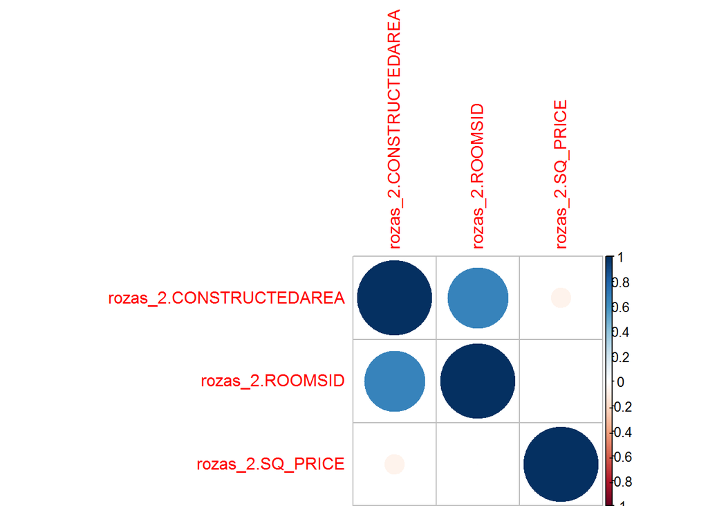

```r
num_vars <- data.frame(rozas_2$CONSTRUCTEDAREA, rozas_2$ROOMSID, rozas_2$SQ_PRICE)
corrmat <- round(cor(num_vars), 2)
corrplot(corrmat, method = "circle")
```

Constructed area and number of rooms are correlated and makes sense, since more area probably implies more rooms. Now I have to drop one of those since they can create collinearity, therefore, we have to check which one is more correlated to the response variable.

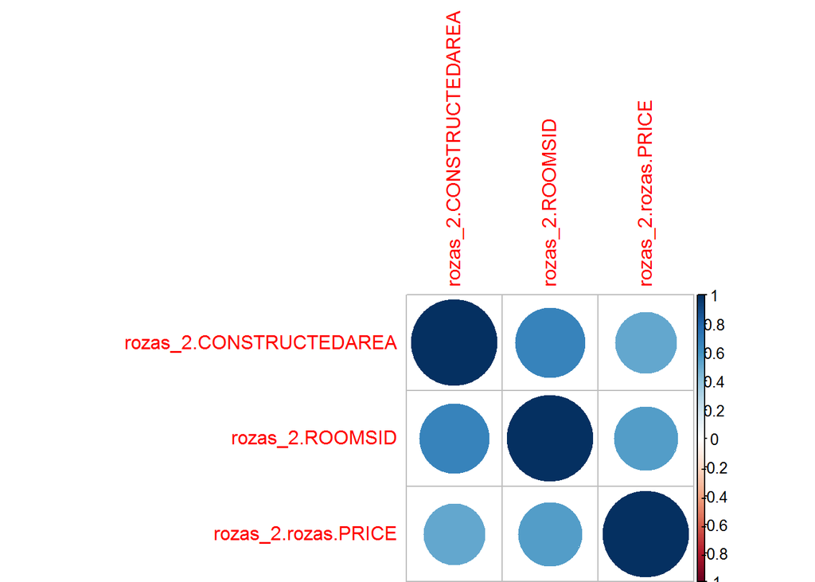

```r
num_vars2 <- data.frame(rozas_2$CONSTRUCTEDAREA, rozas_2$ROOMSID, rozas_2$rozas.PRICE)
corrmat2 <- round(cor(num_vars2), 2)
corrplot(corrmat2, method = "circle")
```

Seems like the price is slightly more positively correlated with the number of rooms than the constructed area so we will pick the number of rooms variable.

```r
rozas_2$CONSTRUCTEDAREA <- NULL
```

Now I will check independency between categorical variables using the chi square test for independence. There are some variables that I suspect might not be independent and we need variables to be orthogonal.

```r
tbl <- table(rozas_2$ROOMSID, rozas_2$HASPARKINGSPACEID)
chisq.test(tbl)
```

```
##
##  Pearson's Chi-squared test
##
## data:  tbl
## X-squared = 766.86, df = 4, p-value < 2.2e-16
```

```r
tbl2 <- table(rozas_2$ROOMSID, rozas_2$HASLIFTID)
chisq.test(tbl2)
```

```
##
##  Pearson's Chi-squared test
##
## data:  tbl2
## X-squared = 2258.1, df = 4, p-value < 2.2e-16
```

```r
tbl3 <- table(rozas_2$HASPARKINGSPACEID, rozas_2$HASLIFTID)
chisq.test(tbl3)
```

```
##
##  Pearson's Chi-squared test with Yates' continuity correction
##
## data:  tbl3
## X-squared = 1.4232, df = 1, p-value = 0.2329
```

Unfortunately, the number of rooms is not independent of a place having parking. In this municipality there are many houses, they all have parking space and probably many rooms too. If the house does not have parking space it is probably a flat which has less rooms.

Same happens with the number of rooms and having a lift. Probably a house with a big number of rooms in Las Rozas is not a flat, therefore, no lift.

Having parking space and having lift are orthogonal variables, we cannot reject the null hypothesis.

Now we have to drop either the variable number of rooms or the other two because they are both not independent of the number of rooms. We will check this by running an ANOVA test.

```r
summary(aov(rozas.PRICE ~ ROOMSID + HASPARKINGSPACEID + HASLIFTID, data = rozas_2))
```

```
##                     Df    Sum Sq   Mean Sq F value   Pr(>F)
## ROOMSID              1 5.590e+13 5.590e+13 2473.38  < 2e-16 ***
## HASPARKINGSPACEID    1 1.429e+12 1.429e+12   63.22 2.23e-15 ***
## HASLIFTID            1 3.120e+12 3.120e+12  138.05  < 2e-16 ***
## Residuals         5420 1.225e+14 2.260e+10
## ---
## Signif. codes:  0 '***' 0.001 '**' 0.01 '*' 0.05 '.' 0.1 ' ' 1
```

The number of rooms is a very explanatory variable of the price of a house, not even the other two combined can explain more information about the price’s variance. Therefore, we have to drop the other two variables.

```r
rozas_2$HASPARKINGSPACEID <- NULL
rozas_2$HASLIFTID <- NULL
```

I checked the most influential variables, the others, even if they are not very significant they do not have strength to introduce too much noise in the model. However, by restricting the learning algorithms, those non significant variables will probably remain out of the predictive model. Now it is time to split the data into train/test and start working on predicting the price of a house.

```r
# shuffle rows and disorder data randomly
rows <- sample(nrow(rozas_2))
rozas_shuffled <- rozas_2[rows,]

# determine 80/20 split indices
split <- round(nrow(rozas_shuffled) * 0.80)


# set train and test sets
rozas_train <- rozas_shuffled[1:split,]
rozas_test <- rozas_shuffled[(split+1):nrow(rozas_shuffled),]
```

The boosted tree has *mstop* hyperparameters to set the number of iterations, the *maxdepth* hyperparameter which is how deep can the tree keep developing branches and the *nu* hyperparameter is shrinkage or learning rate. I left the values untouched so the algorithm will try a combination of iterations.

All the three models have the same training control object parameters, otherwise we would not be able to compare the models if we run different validation methods. I am using the training data to build the model, and later on, we will test these models on the test data and check the out of sample RMSE.

```r
# Fit Linear model: model_lm
model_lm <- train(
  rozas.PRICE ~ ., rozas_train,
  method = "lm",
  preProcess = c('zv', 'center', 'scale'),
  trControl = trainControl(
    method = "cv", number = 5,
    repeats = 1000, verboseIter = FALSE
  )
)

# Fit Random Forest model: model_rf
model_rf <- train(
  rozas.PRICE ~ ., rozas_train,
  method = "ranger",
  tuneLength = 1000,
  tuneGrid = data.frame(mtry = 1:10),
  trControl = trainControl(
    method = "cv", number = 5,
    repeats = 1000, verboseIter = FALSE
  )
)


# Fit Decision Boosted Tree: model_bt
model_bt <- train(
  rozas.PRICE ~ ., rozas_train,
  method = "bstTree",
  trControl = trainControl(
    method = "cv", number = 5,
    repeats = 1000, verboseIter = FALSE
  )
)

# make list of models
model_list <- list(lm = model_lm, rforest = model_rf, boostTree = model_bt)

# Pass model_list to resamples(): resamples
resamples <- resamples(model_list)

# Summarize the results
summary(resamples)
```

```
##
## Call:
## summary.resamples(object = resamples)
##
## Models: lm, rforest, boostTree
## Number of resamples: 5
##
## RMSE
##                Min.   1st Qu.    Median      Mean   3rd Qu.      Max. NA's
## lm        121327.24 125726.32 137321.49 132974.89 140088.65 140410.72    0
## rforest    57067.00  62814.35  62971.64  63586.75  65177.19  69903.56    0
## boostTree  55102.51  55174.89  55627.89  56382.01  57626.54  58378.22    0
##
## Rsquared
##                Min.   1st Qu.    Median      Mean   3rd Qu.      Max. NA's
## lm        0.4270414 0.4388792 0.4697103 0.4880705 0.5518153 0.5529065    0
## rforest   0.8592992 0.8895325 0.8903167 0.8890146 0.8985208 0.9074039    0
## boostTree 0.9011640 0.9051654 0.9102267 0.9083876 0.9122576 0.9131244    0
```

We can observe that despite boosted trees and random forest having a similar R squared, the RMSE is lower in the boost model.

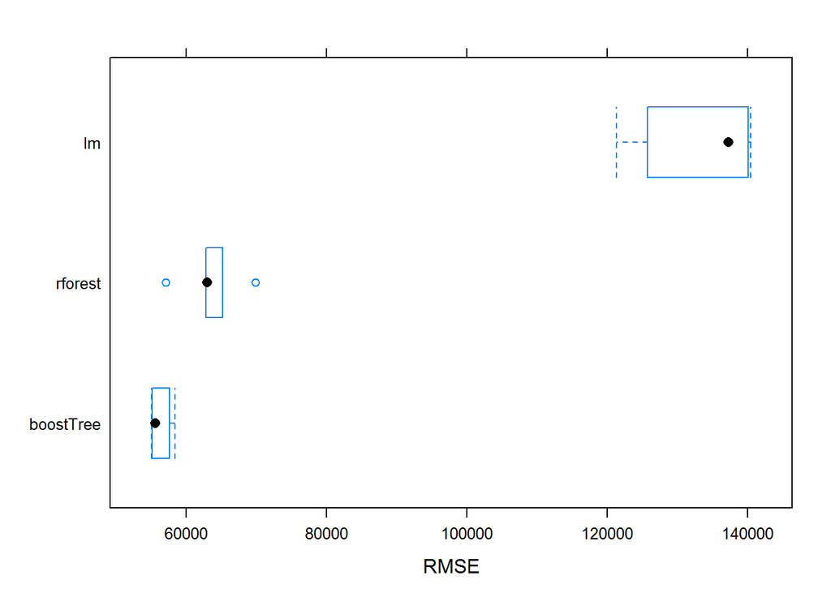

```r
bwplot(resamples, metric = 'RMSE')
```

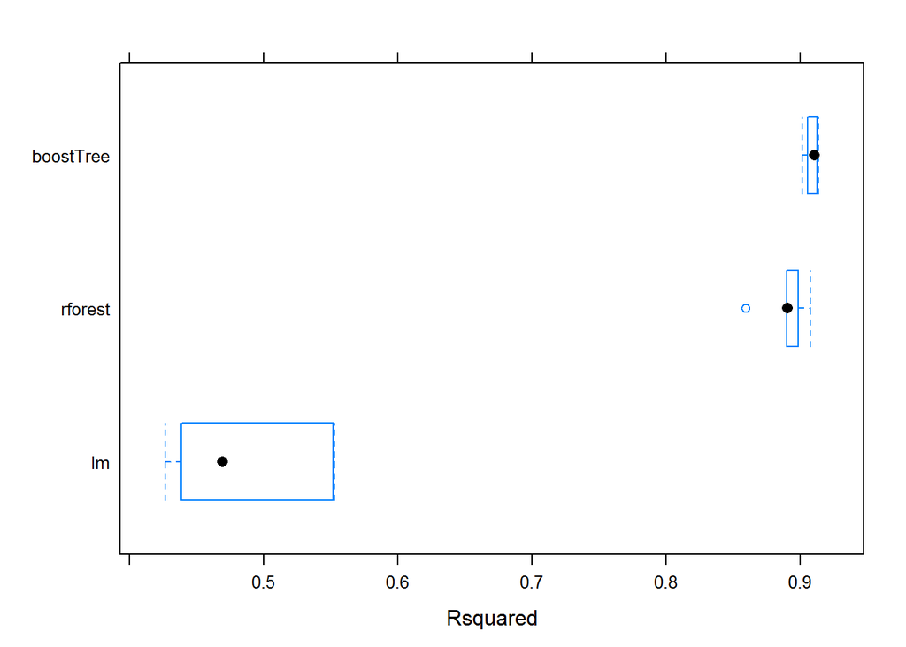

```r
bwplot(resamples, metric = 'Rsquared')
```

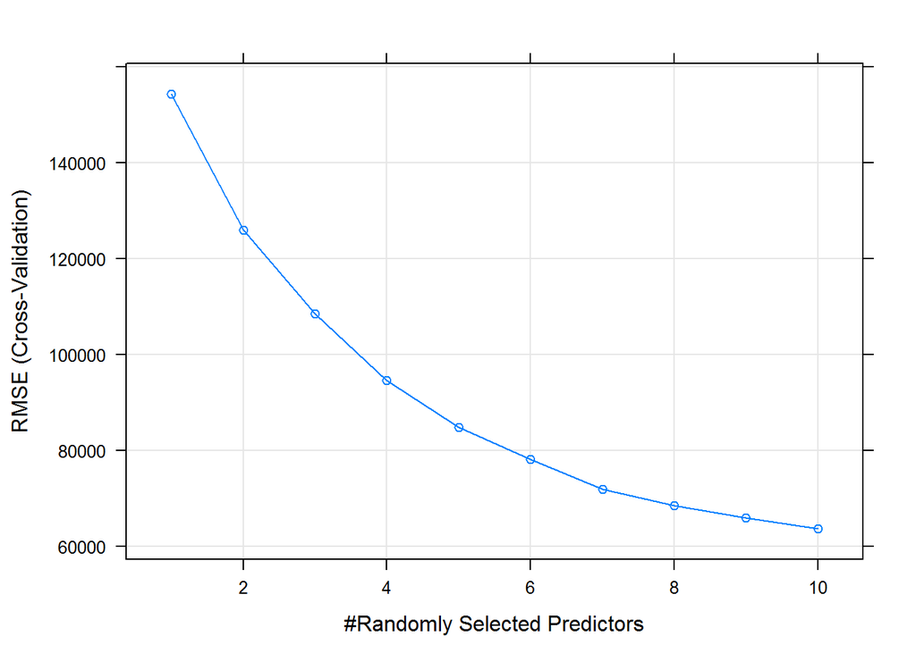

```r
plot(model_rf)
```

We can see in the graph that as we increase the number of variables the RMSE of the random forest model decreases. So why not allow the random forest to pick more variables? because then we might be allowing the individual decision trees generated by the random forest to learn strange rules as a result of overfitting the data.

```r
model_rf$finalModel
```

```
## Ranger result
##
## Call:
##  ranger(.outcome ~ ., data = x, mtry = param$mtry, write.forest = TRUE,      probability = classProbs, ...)
##
## Type:                             Regression
## Number of trees:                  500
## Sample size:                      4339
## Number of independent variables:  52
## Mtry:                             10
## Target node size:                 5
## Variable importance mode:         none
## OOB prediction error (MSE):       3795187689
## R squared (OOB):                  0.8898486
```

```r
summary(model_lm)
```

```
##
## Call:
## lm(formula = .outcome ~ ., data = dat)
##
## Residuals:
##     Min      1Q  Median      3Q     Max
## -662846  -47125   -1007   46930  724872
##
## Coefficients: (4 not defined because of singularities)
##                            Estimate Std. Error t value Pr(>|t|)
## (Intercept)               369152.70    1995.40 185.002  < 2e-16 ***
## AREARANGETK.11             13753.07    2905.77   4.733 2.28e-06 ***
## AREARANGETK.21             57767.80    6815.41   8.476  < 2e-16 ***
## AREARANGETK.31             79703.42    8218.82   9.698  < 2e-16 ***
## AREARANGETK.41            107090.72    9500.77  11.272  < 2e-16 ***
## AREARANGETK.51            127066.89   10048.03  12.646  < 2e-16 ***
## AREARANGETK.61            128418.25    9429.46  13.619  < 2e-16 ***
## AREARANGETK.71            109281.49    7488.86  14.593  < 2e-16 ***
## AREARANGETK.81             88934.84    5966.32  14.906  < 2e-16 ***
## AREARANGETK.91             78566.16    5151.36  15.252  < 2e-16 ***
## AREARANGETK.101           228224.88   11336.02  20.133  < 2e-16 ***
## AREARANGETK.111           137707.63    6608.85  20.837  < 2e-16 ***
## AREARANGETK.121            30623.09    3018.57  10.145  < 2e-16 ***
## AREARANGETK.131             5541.53    2712.02   2.043 0.041082 *
## AREARANGETK.141              -16.24    2156.23  -0.008 0.993990
## AREARANGETK.151                  NA         NA      NA       NA
## ROOMSID                    23330.19    4121.89   5.660 1.61e-08 ***
## HASAIRCONDITIONINGID1       3380.19    2061.30   1.640 0.101113
## HASSWIMMINGPOOLID1          3815.79    2812.16   1.357 0.174888
## HASTERRACEID1               4987.09    2204.26   2.262 0.023717 *
## HASGARDENID1                2912.66    2852.87   1.021 0.307331
## ISINVOICEID1                9946.53    2628.89   3.784 0.000157 ***
## ENERGYCERTIFICATIONID..11   2742.34    2672.44   1.026 0.304876
## ENERGYCERTIFICATIONID.11     892.65    2048.26   0.436 0.662997
## ENERGYCERTIFICATIONID.21    3478.42    2275.76   1.528 0.126470
## ENERGYCERTIFICATIONID.31   -2531.48    2057.05  -1.231 0.218527
## ENERGYCERTIFICATIONID.41     902.90    2081.04   0.434 0.664405
## ENERGYCERTIFICATIONID.51    -704.44    2116.50  -0.333 0.739277
## ENERGYCERTIFICATIONID.61    -427.49    2156.36  -0.198 0.842861
## ENERGYCERTIFICATIONID.71    1233.64    2030.29   0.608 0.543472
```

[output cut: 14 more lines]

```
## YEAR.20111                 18975.35    2724.13   6.966 3.77e-12 ***
## YEAR.20121                  8935.50    2682.45   3.331 0.000872 ***
## YEAR.20131                  4581.35    2603.13   1.760 0.078489 .
## YEAR.20141                  5524.78    2760.04   2.002 0.045380 *
## YEAR.20151                  5863.89    2906.54   2.017 0.043708 *
## YEAR.20161                  8455.40    2784.87   3.036 0.002410 **
## YEAR.20171                  8342.40    2299.00   3.629 0.000288 ***
## SQ_PRICE                   27508.44    2120.61  12.972  < 2e-16 ***
## ISFLAT1                   -10818.30   19775.73  -0.547 0.584373
## ---
## Signif. codes:  0 '***' 0.001 '**' 0.01 '*' 0.05 '.' 0.1 ' ' 1
##
## Residual standard error: 131400 on 4290 degrees of freedom
## Multiple R-squared:  0.5041, Adjusted R-squared:  0.4986
## F-statistic: 90.86 on 48 and 4290 DF,  p-value: < 2.2e-16
```

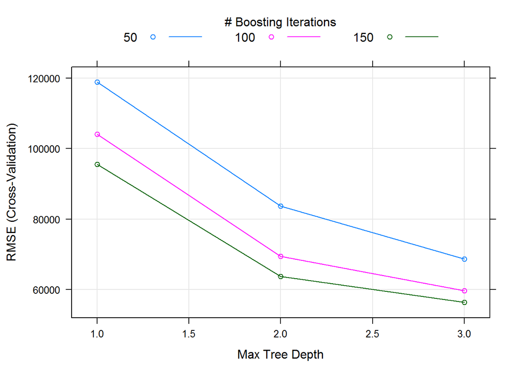

```r
plot(model_bt)
```

If hyperparameters are not specified, it will try a combination of boosting iterations. In the random forest model I limited how much it could grow, I did not limit the amount of iterations that the boosting algorithm can do so it could result in overfitting out of sample. By default, the *maxdepth* hyperparameter is set up to 3.

Now we will used the trained models to predict values using the characteristics of the house in the test data set. Then we will compute the out of sample RMSE by comparing these predicted results with the real results.

```r
test_data <- rozas_test[-1]

prediction_lm <- predict(model_lm, test_data)
errors_lm <- rozas_test$rozas.PRICE - prediction_lm
rmse_lm <- sqrt(mean(errors_lm^2))

prediction_bt <- predict(model_bt, test_data)
errors_bt <- rozas_test$rozas.PRICE - prediction_bt
rmse_bt <- sqrt(mean(errors_bt^2))

prediction_rf <- predict(model_rf, test_data)
errors_rf <- rozas_test$rozas.PRICE - prediction_rf
rmse_rf <- sqrt(mean(errors_rf^2))

rmse <- data.frame(rmse_lm = rmse_lm, rmse_bt = rmse_bt, rmse_rf = rmse_rf)
rmse
```

```
##    rmse_lm  rmse_bt  rmse_rf
## 1 124438.5 53070.37 57917.93
```

Seems like the boosting model did the best fit, followed closely by random forest. We can have a clearer vision of this by plotting and comparing the real value of price versus the fitted values of each model.

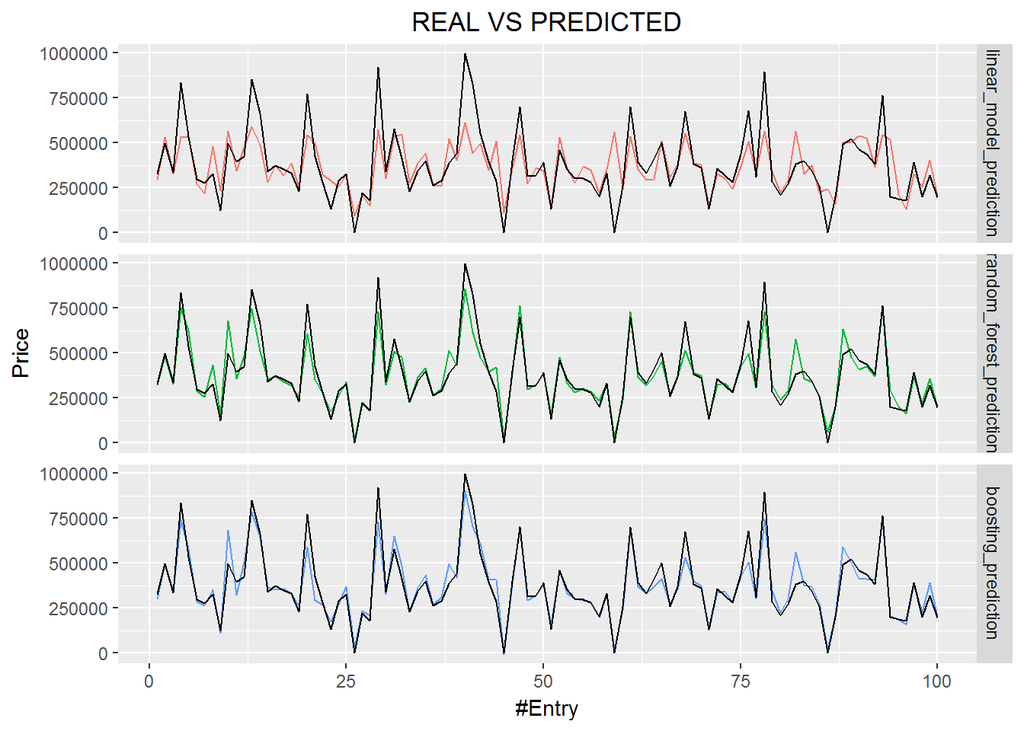

```r
predictions <- data.frame(Price = rozas_test$rozas.PRICE,
                          linear_model_prediction = prediction_lm,
                          random_forest_prediction = prediction_rf,
                          boosting_prediction = prediction_bt,
                          index = 1:nrow(rozas_test))

toPlot <- melt(predictions, id.vars = c('Price', 'index'))

ggplot() +
  geom_line(data = subset(toPlot, index <= 100), aes(y = value, x = index, col = variable))+
  facet_grid(variable ~.) +
  geom_line(data = subset(toPlot, index <= 100), aes(y = Price, x = index)) +
  theme(legend.position="none", plot.title = element_text(hjust = 0.5)) +
  ggtitle('REAL VS PREDICTED') +
  ylab('Price') +
  xlab('#Entry')
```

As it was expected, boosting performed the best. However, all the models performed quite well in out of sample data, probably the common training control settings had something to do with this. Many times quality of data plays a key roll, since extremely flexible models such as random forest or boosting can follow noise very closely.